# Ficha de Información Metropolitana

Universidad Autónoma Metropolitnana

Lic. Martínez Rodriguez, Alvaro[^1]

Lic. Pérez Victorino, Leonardo[^2]

La ficha de información metropolitana es una herramienta valiosa para la planificación territorial en zonas metropolitanas (ZM). Proporciona información censal en diferentes formatos, como gráficos, tablas y mapas, tanto de los Censos de Población y Vivienda, 2020 (CPV2020) como de los Censos Económicos de 1999, 2004, 2009, 2014 y 2019. Ambos publicados por el Instituto Nacional de Estadística y Geografía (INEGI).

## Información general de la Zona Metropolitana de Ocotlán

Según (Sedatu 2018), la zona metropolitana se define como un área urbana que consta de una ciudad principal y su zona conurbada. Las zonas metropolitanas se caracterizan por tener una alta densidad de población y estar interconectadas por vías de transporte y comunicación. La zona metropolitana de Ocotlán, se localiza en Jalisco. y esta compuesta por 3 municipios, que se muestran a continuación:

| Nombre | Clave |
| --- | --- |
| Jamay | 14047 |
| Ocotlán | 14063 |
| Poncitlán | 14066 |

Municipios de la zona metropolitana

Además, se presenta un mapa de la zona metropolitana:

[interactive chart not shown]

A continuación se presentan algunos datos generales sobre esta zona:

## Información sociodemográfica

La estructura de población de la zona metropolitana de Ocotlán se presenta en la una piramide poblacional ya que permite obtener una visión general de la distribución de la población por género y edad:

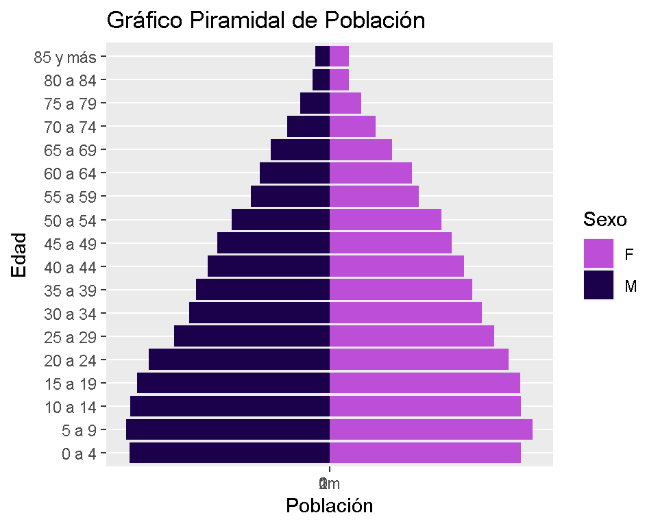

En el siguiente mapa se observa como se distribuye la población sobre la región:

[interactive chart not shown]

### Grupos de población

- Población total respecto al país: 0%. Este valor indica el peso poblacional de la zona metropolitana en relación con la población total de México.
- Población Masculina: 49%
- Población Femenina: 51%
- Relación M-F: 97.453. Este valor indica la proporción de hombres por cada mujer en la zona metropolitana.

### Socioeconómicos

La población en terminos de la poblacioón economicamente activa esta descrita por:

- Porcentaje de población de 12 años y más económicamente activa: 48%
- Porcentaje de población de 12 años y más no económicamente activa: 29% `

### Educación

La educación de la zona metropolitana esta caracterizada por los siguientes estadísticos:

- Porcentaje de población de 15 años y más sin escolaridad:3%
- Porcentaje de población de 15 años y más con al menos un grado aprobado en primaria: 71%
- Porcentaje de población de 15 años y más con educación básica completa: 18%
- Porcentaje de población de 15 años y más con secundaria o equivalente incompleta:3%
- Porcentaje de población de 18 años y más con al menos un grado aprobado en educación media superior: 24%

### Salud

La situación de la afiliación a algún servico de salud es la siguiente:

- Porcentaje de población afiliada a servicios de salud: 73%
- Población sin afiliación a servicios de salud:49721

### Indicadores de desarrollo

IDH es un indicador elaborado por el Programa de Naciones Unidas para el Desarrollo (PNUD), este busca medir la calidad de vida, así como el progreso socioeconómico de cada entidad y municipio; El cálculo del Índice de Desarrollo Humano se realiza a partir de las tres variables: esperanza de vida, educación e ingreso per cápita.

- Muy Alto - IDH mayor de 1.
- Alto - IDH entre 0.80 a 1.
- Medio - IDH entre 0.50 y 0.80.
- Bajo - IDH entre 0 y 0.50
- Muy Bajo - IDH menores a 0.
- El promedio del IDH en 2020 para la zona metropolitana es de 0.729 según datos del PNUD.

El IM es un índice construido por el consejo Nacional de Población (CONAPO). Este índice considera 4 dimensiones estructurales para su construcción: vivienda, ingreso, educación y distribución de la población. El indice se puede ubicar en 5 estratos designados por la ténica de estratificación de Dalenius-Hodges..

Por último, el IRS es construido por el Consejo Nacional de Evaluación de la Política de Desarrollo Social, CONEVAL, este índice incorpora indicadores de educación, de acceso a servicios de salud, de servicios básicos y tiene como finalidad ordenar los municipios según sus carencias sociales. Este índice, al igual que el IM, se clasifica en cinco estratos.

## Datos económicos.

Con base en la información de los subsectores de los 21 sectores principales de la clasificación del SCIAN, extraída de los Censos Económicos del INEGI durante el periodo de 1998-2018, se ha llevado a cabo la agrupación de los datos de cada municipio que pertenece a una zona metropolitana en cinco grandes sectores: Primarios, Construcción, Manufactura, Comercio y Servicios. Esta clasificación se basa en la metodología proporcionada por el INEGI. Se utilizaron las siguientes variables:

- Unidades económicas (UE) [número de unidades]
- Activiso fijos totales (AF) [miles de pesos a precios corrientes]
- Formación bruta de capital fijo (FB) [miles de pesos a precios corrientes]
- Producción bruta total (PB) [miles de pesos a precios corrientes]
- Personal ocupado total (PO) [número de personas]
- Total de remuneraciones (RE) [miles de pesos a precios corrientes]
- Valor agregado censal bruto (VA) [miles de pesos a precios corrientes]

Posteriormente, se replica la metodología utilizada por García y Carranco (2008) para estimar los coeficientes de participación relativa (PR), de localización de la actividad económica (QL), Hirschman-Herfindahl (HH) e Inverso de Hirschman-Herfindahl (IHH).

$PR_ij$=$X_ij/X_in$

$QL_ij$=$(X_ij⁄X_j )/(X_in⁄X_n)$

$HH_ij$=$X_ij/X_in - X_j/X_n$

$IHH_ij$=$1/(X_ij/X_in - X_j/X_n)$

### Cifras brutas

#### 1999

##### UE

| Clave | Municipio | Primarios | Construcción | Manufactura | Comercio | Servicios |
| --- | --- | --- | --- | --- | --- | --- |
| 14047 | Jamay | 11 | 0 | 87 | 316 | 136 |
| 14063 | Ocotlán | 0 | 22 | 579 | 1,839 | 1,134 |
| 14066 | Poncitlán | 15 | 0 | 108 | 578 | 103 |

##### AF

| Clave | Municipio | Primarios | Construcción | Manufactura | Comercio | Servicios |
| --- | --- | --- | --- | --- | --- | --- |
| 14047 | Jamay | 1,087 | 0 | 25,835 | 23,761 | 25,575 |
| 14063 | Ocotlán | 2,707 | 10,318 | 320,255 | 144,629 | 217,630 |
| 14066 | Poncitlán | 4,301 | 0 | 1,025,669 | 39,322 | 29,436 |

##### FB

| Clave | Municipio | Primarios | Construcción | Manufactura | Comercio | Servicios |
| --- | --- | --- | --- | --- | --- | --- |
| 14047 | Jamay | 30 | 0 | 2,234 | 1,327 | 242 |
| 14063 | Ocotlán | 110 | 2,566 | 47,120 | 8,375 | 10,225 |
| 14066 | Poncitlán | 65 | 0 | 108,795 | 970 | 545 |

##### PB

| Clave | Municipio | Primarios | Construcción | Manufactura | Comercio | Servicios |
| --- | --- | --- | --- | --- | --- | --- |
| 14047 | Jamay | 3,250 | 0 | 67,956 | 19,092 | 15,981 |
| 14063 | Ocotlán | 4,094 | 43,834 | 1,949,615 | 372,208 | 325,482 |
| 14066 | Poncitlán | 1,350 | 0 | 2,824,802 | 34,086 | 29,139 |

##### PO

| Clave | Municipio | Primarios | Construcción | Manufactura | Comercio | Servicios |
| --- | --- | --- | --- | --- | --- | --- |
| 14047 | Jamay | 96 | 0 | 344 | 509 | 414 |
| 14063 | Ocotlán | 121 | 729 | 5,530 | 4,140 | 3,350 |
| 14066 | Poncitlán | 438 | 0 | 4,023 | 1,012 | 588 |

##### RE

| Clave | Municipio | Primarios | Construcción | Manufactura | Comercio | Servicios |
| --- | --- | --- | --- | --- | --- | --- |
| 14047 | Jamay | 0 | 0 | 2,959 | 1,057 | 1,452 |
| 14063 | Ocotlán | 0 | 15,212 | 151,374 | 57,632 | 41,764 |
| 14066 | Poncitlán | 5 | 0 | 453,511 | 5,271 | 6,421 |

##### VA

| Clave | Municipio | Primarios | Construcción | Manufactura | Comercio | Servicios |
| --- | --- | --- | --- | --- | --- | --- |
| 14047 | Jamay | 2,148 | 0 | 10,846 | 16,156 | 7,166 |
| 14063 | Ocotlán | 1,071 | 18,791 | 727,410 | 285,303 | 207,947 |
| 14066 | Poncitlán | 360 | 0 | 1,132,686 | 23,702 | 9,316 |

#### 2004

##### UE

| Clave | Municipio | Primarios | Construcción | Manufactura | Comercio | Servicios |
| --- | --- | --- | --- | --- | --- | --- |
| 14047 | Jamay | 0 | 0 | 85 | 388 | 105 |
| 14063 | Ocotlán | 0 | 8 | 624 | 2,132 | 1,265 |
| 14066 | Poncitlán | 13 | 0 | 120 | 709 | 149 |

##### AF

| Clave | Municipio | Primarios | Construcción | Manufactura | Comercio | Servicios |
| --- | --- | --- | --- | --- | --- | --- |
| 14047 | Jamay | 2,026 | 0 | 21,221 | 22,185 | 20,098 |
| 14063 | Ocotlán | 2,526 | 100,233 | 1,574,419 | 389,340 | 546,183 |
| 14066 | Poncitlán | 4,668 | 557 | 3,787,189 | 67,811 | 38,545 |

##### FB

| Clave | Municipio | Primarios | Construcción | Manufactura | Comercio | Servicios |
| --- | --- | --- | --- | --- | --- | --- |
| 14047 | Jamay | 112 | 0 | 961 | 2,394 | 993 |
| 14063 | Ocotlán | 150 | 12,621 | 36,090 | 21,065 | 14,363 |
| 14066 | Poncitlán | 265 | 555 | 10,025 | 1,471 | 1,146 |

##### PB

| Clave | Municipio | Primarios | Construcción | Manufactura | Comercio | Servicios |
| --- | --- | --- | --- | --- | --- | --- |
| 14047 | Jamay | 4,118 | 0 | 136,976 | 63,749 | 33,266 |
| 14063 | Ocotlán | 8,025 | 126,715 | 1,802,336 | 729,371 | 637,541 |
| 14066 | Poncitlán | 8,321 | 1,442 | 2,415,165 | 121,327 | 49,531 |

##### PO

| Clave | Municipio | Primarios | Construcción | Manufactura | Comercio | Servicios |
| --- | --- | --- | --- | --- | --- | --- |
| 14047 | Jamay | 106 | 0 | 474 | 837 | 482 |
| 14063 | Ocotlán | 119 | 592 | 5,367 | 5,666 | 4,132 |
| 14066 | Poncitlán | 277 | 62 | 3,395 | 1,484 | 816 |

##### RE

| Clave | Municipio | Primarios | Construcción | Manufactura | Comercio | Servicios |
| --- | --- | --- | --- | --- | --- | --- |
| 14047 | Jamay | 328 | 0 | 10,478 | 6,284 | 2,883 |
| 14063 | Ocotlán | 0 | 17,046 | 221,650 | 114,362 | 70,707 |
| 14066 | Poncitlán | 1,432 | 1,268 | 356,835 | 18,780 | 7,745 |

##### VA

| Clave | Municipio | Primarios | Construcción | Manufactura | Comercio | Servicios |
| --- | --- | --- | --- | --- | --- | --- |
| 14047 | Jamay | 2,472 | 0 | 34,315 | 50,838 | 16,801 |
| 14063 | Ocotlán | 5,660 | 32,096 | 428,770 | 536,768 | 388,320 |
| 14066 | Poncitlán | 7,143 | 1,067 | 743,142 | 90,672 | 22,530 |

#### 2009

##### UE

| Clave | Municipio | Primarios | Construcción | Manufactura | Comercio | Servicios |
| --- | --- | --- | --- | --- | --- | --- |
| 14047 | Jamay | 0 | 0 | 54 | 403 | 85 |
| 14063 | Ocotlán | 0 | 18 | 631 | 2,229 | 1,622 |
| 14066 | Poncitlán | 13 | 0 | 146 | 749 | 194 |

##### AF

| Clave | Municipio | Primarios | Construcción | Manufactura | Comercio | Servicios |
| --- | --- | --- | --- | --- | --- | --- |
| 14047 | Jamay | 19,906 | 0 | 28,449 | 59,991 | 21,861 |
| 14063 | Ocotlán | 43,493 | 128,103 | 1,263,957 | 374,688 | 567,345 |
| 14066 | Poncitlán | 8,325 | 7,768 | 1,915,113 | 171,198 | 103,051 |

##### FB

| Clave | Municipio | Primarios | Construcción | Manufactura | Comercio | Servicios |
| --- | --- | --- | --- | --- | --- | --- |
| 14047 | Jamay | 3,274 | 0 | 582 | 1,846 | 100 |
| 14063 | Ocotlán | 0 | 16,198 | 53,117 | 32,241 | 28,104 |
| 14066 | Poncitlán | 48 | 122 | 9,730 | 6,470 | 5,158 |

##### PB

| Clave | Municipio | Primarios | Construcción | Manufactura | Comercio | Servicios |
| --- | --- | --- | --- | --- | --- | --- |
| 14047 | Jamay | 22,335 | 0 | 102,923 | 136,688 | 42,400 |
| 14063 | Ocotlán | 53,703 | 265,734 | 5,063,422 | 821,734 | 904,488 |
| 14066 | Poncitlán | 5,751 | 10,350 | 3,099,329 | 166,619 | 98,529 |

##### PO

| Clave | Municipio | Primarios | Construcción | Manufactura | Comercio | Servicios |
| --- | --- | --- | --- | --- | --- | --- |
| 14047 | Jamay | 239 | 0 | 278 | 1,109 | 663 |
| 14063 | Ocotlán | 287 | 554 | 4,497 | 7,110 | 5,695 |
| 14066 | Poncitlán | 389 | 36 | 2,047 | 2,045 | 1,359 |

##### RE

| Clave | Municipio | Primarios | Construcción | Manufactura | Comercio | Servicios |
| --- | --- | --- | --- | --- | --- | --- |
| 14047 | Jamay | 1,499 | 0 | 7,772 | 6,351 | 4,034 |
| 14063 | Ocotlán | 2,069 | 31,598 | 205,270 | 158,012 | 125,840 |
| 14066 | Poncitlán | 737 | 2,577 | 272,640 | 25,685 | 10,739 |

##### VA

| Clave | Municipio | Primarios | Construcción | Manufactura | Comercio | Servicios |
| --- | --- | --- | --- | --- | --- | --- |
| 14047 | Jamay | 13,508 | 0 | 20,492 | 51,463 | 17,685 |
| 14063 | Ocotlán | 34,507 | 79,884 | 3,012,617 | 510,707 | 411,713 |
| 14066 | Poncitlán | 2,776 | 5,043 | 827,168 | 115,709 | 45,835 |

#### 2014

##### UE

| Clave | Municipio | Primarios | Construcción | Manufactura | Comercio | Servicios |
| --- | --- | --- | --- | --- | --- | --- |
| 14047 | Jamay | 20 | 0 | 131 | 564 | 321 |
| 14063 | Ocotlán | 0 | 6 | 696 | 2,338 | 1,719 |
| 14066 | Poncitlán | 14 | 0 | 175 | 907 | 545 |

##### AF

| Clave | Municipio | Primarios | Construcción | Manufactura | Comercio | Servicios |
| --- | --- | --- | --- | --- | --- | --- |
| 14047 | Jamay | 55,776 | 0 | 30,738 | 104,366 | 43,152 |
| 14063 | Ocotlán | 0 | 114,321 | 1,458,429 | 631,591 | 518,194 |
| 14066 | Poncitlán | 7,587 | 0 | 3,870,778 | 174,924 | 62,067 |

##### FB

| Clave | Municipio | Primarios | Construcción | Manufactura | Comercio | Servicios |
| --- | --- | --- | --- | --- | --- | --- |
| 14047 | Jamay | 4 | 0 | 1,466 | 11,423 | 7,333 |
| 14063 | Ocotlán | 0 | 3,159 | 46,293 | 39,600 | 36,260 |
| 14066 | Poncitlán | 80 | 0 | 15,249 | 13,110 | 3,756 |

##### PB

| Clave | Municipio | Primarios | Construcción | Manufactura | Comercio | Servicios |
| --- | --- | --- | --- | --- | --- | --- |
| 14047 | Jamay | 14,441 | 0 | 80,753 | 133,083 | 55,669 |
| 14063 | Ocotlán | 0 | 177,214 | 6,587,995 | 865,185 | 899,889 |
| 14066 | Poncitlán | 8,586 | 0 | 4,373,510 | 307,938 | 107,149 |

##### PO

| Clave | Municipio | Primarios | Construcción | Manufactura | Comercio | Servicios |
| --- | --- | --- | --- | --- | --- | --- |
| 14047 | Jamay | 269 | 0 | 421 | 1,276 | 660 |
| 14063 | Ocotlán | 0 | 301 | 5,372 | 5,882 | 4,593 |
| 14066 | Poncitlán | 356 | 0 | 2,086 | 1,978 | 1,093 |

##### RE

| Clave | Municipio | Primarios | Construcción | Manufactura | Comercio | Servicios |
| --- | --- | --- | --- | --- | --- | --- |
| 14047 | Jamay | 1,517 | 0 | 8,178 | 6,601 | 4,979 |
| 14063 | Ocotlán | 0 | 20,415 | 362,382 | 123,663 | 101,596 |
| 14066 | Poncitlán | 9 | 0 | 302,019 | 25,013 | 15,719 |

##### VA

| Clave | Municipio | Primarios | Construcción | Manufactura | Comercio | Servicios |
| --- | --- | --- | --- | --- | --- | --- |
| 14047 | Jamay | 5,740 | 0 | 14,293 | 70,660 | 28,416 |
| 14063 | Ocotlán | 0 | 58,134 | 3,814,949 | 577,381 | 390,557 |
| 14066 | Poncitlán | 5,060 | 0 | 1,365,904 | 191,855 | 54,105 |

#### 2019

##### UE

| Clave | Municipio | Primarios | Construcción | Manufactura | Comercio | Servicios |
| --- | --- | --- | --- | --- | --- | --- |
| 14047 | Jamay | 31 | 2 | 139 | 643 | 425 |
| 14063 | Ocotlán | 10 | 20 | 836 | 2,674 | 2,344 |
| 14066 | Poncitlán | 17 | 3 | 254 | 1,046 | 776 |

##### AF

| Clave | Municipio | Primarios | Construcción | Manufactura | Comercio | Servicios |
| --- | --- | --- | --- | --- | --- | --- |
| 14047 | Jamay | 58,475 | 0 | 36,228 | 131,337 | 44,762 |
| 14063 | Ocotlán | 0 | 356,523 | 3,754,728 | 2,401,715 | 943,236 |
| 14066 | Poncitlán | 11,845 | 9,450 | 3,816,222 | 354,872 | 184,976 |

##### FB

| Clave | Municipio | Primarios | Construcción | Manufactura | Comercio | Servicios |
| --- | --- | --- | --- | --- | --- | --- |
| 14047 | Jamay | 1,380 | 0 | 288 | 269 | 488 |
| 14063 | Ocotlán | 0 | 22,627 | 280,643 | 43,818 | 29,882 |
| 14066 | Poncitlán | 256 | -752 | 26,975 | 4,971 | 12,049 |

##### PB

| Clave | Municipio | Primarios | Construcción | Manufactura | Comercio | Servicios |
| --- | --- | --- | --- | --- | --- | --- |
| 14047 | Jamay | 43,690 | 0 | 246,740 | 280,913 | 108,932 |
| 14063 | Ocotlán | 0 | 479,585 | 11,428,490 | 2,288,795 | 1,897,558 |
| 14066 | Poncitlán | 42,073 | 20,438 | 6,901,388 | 525,218 | 275,990 |

##### PO

| Clave | Municipio | Primarios | Construcción | Manufactura | Comercio | Servicios |
| --- | --- | --- | --- | --- | --- | --- |
| 14047 | Jamay | 287 | 0 | 512 | 1,297 | 856 |
| 14063 | Ocotlán | 0 | 889 | 7,867 | 7,645 | 6,957 |
| 14066 | Poncitlán | 349 | 46 | 3,034 | 2,242 | 1,587 |

##### RE

| Clave | Municipio | Primarios | Construcción | Manufactura | Comercio | Servicios |
| --- | --- | --- | --- | --- | --- | --- |
| 14047 | Jamay | 15,199 | 0 | 23,557 | 18,075 | 13,080 |
| 14063 | Ocotlán | 0 | 55,072 | 550,275 | 296,584 | 254,070 |
| 14066 | Poncitlán | 15,969 | 6,144 | 360,554 | 45,047 | 31,373 |

##### VA

| Clave | Municipio | Primarios | Construcción | Manufactura | Comercio | Servicios |
| --- | --- | --- | --- | --- | --- | --- |
| 14047 | Jamay | 23,241 | 0 | 67,595 | 216,147 | 52,546 |
| 14063 | Ocotlán | 0 | 144,346 | 3,320,708 | 1,561,607 | 974,750 |
| 14066 | Poncitlán | 23,763 | 7,429 | 2,961,670 | 436,599 | 128,668 |

### Coeficientes de localización (QL)

#### 1999

##### UE

| Clave | Municipio | Primarios | Construcción | Manufactura | Comercio | Servicios |
| --- | --- | --- | --- | --- | --- | --- |
| 14047 | Jamay | 7.5303 | 0.0000 | 1.4256 | 1.0889 | 0.7008 |
| 14063 | Ocotlán | 0.0000 | 1.0351 | 1.4601 | 0.9752 | 0.8993 |
| 14066 | Poncitlán | 7.0246 | 0.0000 | 1.2107 | 1.3625 | 0.3631 |

##### AF

| Clave | Municipio | Primarios | Construcción | Manufactura | Comercio | Servicios |
| --- | --- | --- | --- | --- | --- | --- |
| 14047 | Jamay | 0.5857 | 0.0000 | 0.9957 | 4.1026 | 0.6162 |
| 14063 | Ocotlán | 0.1599 | 0.9743 | 1.3533 | 2.7379 | 0.5749 |
| 14066 | Poncitlán | 0.1608 | 0.0000 | 2.7436 | 0.4712 | 0.0492 |

##### FB

[output not shown]

##### PB

| Clave | Municipio | Primarios | Construcción | Manufactura | Comercio | Servicios |
| --- | --- | --- | --- | --- | --- | --- |
| 14047 | Jamay | 3.0644 | 0.0000 | 1.2922 | 1.2856 | 0.4708 |
| 14063 | Ocotlán | 0.1522 | 0.4507 | 1.4619 | 0.9883 | 0.3781 |
| 14066 | Poncitlán | 0.0468 | 0.0000 | 1.9758 | 0.0844 | 0.0316 |

##### PO

| Clave | Municipio | Primarios | Construcción | Manufactura | Comercio | Servicios |
| --- | --- | --- | --- | --- | --- | --- |
| 14047 | Jamay | 7.9403 | 0.0000 | 0.8176 | 1.4393 | 0.8225 |
| 14063 | Ocotlán | 0.9835 | 0.9788 | 1.2916 | 1.1504 | 0.6541 |
| 14066 | Poncitlán | 8.1469 | 0.0000 | 2.1502 | 0.6435 | 0.2627 |

##### RE

| Clave | Municipio | Primarios | Construcción | Manufactura | Comercio | Servicios |
| --- | --- | --- | --- | --- | --- | --- |
| 14047 | Jamay | 0e+00 | 0.0000 | 1.4636 | 1.3613 | 0.5885 |
| 14063 | Ocotlán | 0e+00 | 2.2255 | 1.5392 | 1.5259 | 0.3480 |
| 14066 | Poncitlán | 9e-04 | 0.0000 | 2.6366 | 0.0798 | 0.0306 |

##### VA

| Clave | Municipio | Primarios | Construcción | Manufactura | Comercio | Servicios |
| --- | --- | --- | --- | --- | --- | --- |
| 14047 | Jamay | 5.0306 | 0.0000 | 0.8106 | 1.9973 | 0.5265 |
| 14063 | Ocotlán | 0.0734 | 0.6813 | 1.5915 | 1.0325 | 0.4472 |
| 14066 | Poncitlán | 0.0263 | 0.0000 | 2.6364 | 0.0913 | 0.0213 |

#### 2004

##### UE

| Clave | Municipio | Primarios | Construcción | Manufactura | Comercio | Servicios |
| --- | --- | --- | --- | --- | --- | --- |
| 14047 | Jamay | 0.0000 | 0.0000 | 1.5045 | 1.2433 | 0.5109 |
| 14063 | Ocotlán | 0.0000 | 0.4013 | 1.5845 | 0.9801 | 0.8830 |
| 14066 | Poncitlán | 7.2847 | 0.0000 | 1.2388 | 1.3250 | 0.4229 |

##### AF

| Clave | Municipio | Primarios | Construcción | Manufactura | Comercio | Servicios |
| --- | --- | --- | --- | --- | --- | --- |
| 14047 | Jamay | 1.8590 | 0.0000 | 0.8839 | 3.7643 | 0.5943 |
| 14063 | Ocotlán | 0.0581 | 3.4918 | 1.6449 | 1.6569 | 0.4051 |
| 14066 | Poncitlán | 0.0720 | 0.0130 | 2.6515 | 0.1934 | 0.0192 |

##### FB

[output not shown]

##### PB

| Clave | Municipio | Primarios | Construcción | Manufactura | Comercio | Servicios |
| --- | --- | --- | --- | --- | --- | --- |
| 14047 | Jamay | 1.6925 | 0.0000 | 1.2455 | 1.9492 | 0.3893 |
| 14063 | Ocotlán | 0.2377 | 1.2117 | 1.1810 | 1.6072 | 0.5377 |
| 14066 | Poncitlán | 0.3137 | 0.0176 | 2.0144 | 0.3403 | 0.0532 |

##### PO

| Clave | Municipio | Primarios | Construcción | Manufactura | Comercio | Servicios |
| --- | --- | --- | --- | --- | --- | --- |
| 14047 | Jamay | 6.7531 | 0.0000 | 0.9473 | 1.5076 | 0.6514 |
| 14063 | Ocotlán | 0.9068 | 0.8061 | 1.2830 | 1.2207 | 0.6680 |
| 14066 | Poncitlán | 5.5539 | 0.2221 | 2.1354 | 0.8412 | 0.3471 |

##### RE

| Clave | Municipio | Primarios | Construcción | Manufactura | Comercio | Servicios |
| --- | --- | --- | --- | --- | --- | --- |
| 14047 | Jamay | 1.7250 | 0.0000 | 1.4958 | 2.0125 | 0.3156 |
| 14063 | Ocotlán | 0.0000 | 1.5404 | 1.4914 | 1.7262 | 0.3649 |
| 14066 | Poncitlán | 0.3896 | 0.1258 | 2.6355 | 0.3112 | 0.0439 |

##### VA

| Clave | Municipio | Primarios | Construcción | Manufactura | Comercio | Servicios |
| --- | --- | --- | --- | --- | --- | --- |
| 14047 | Jamay | 1.4692 | 0.0000 | 1.0110 | 2.4712 | 0.3661 |
| 14063 | Ocotlán | 0.2524 | 1.0321 | 0.9479 | 1.9579 | 0.6349 |
| 14066 | Poncitlán | 0.5128 | 0.0552 | 2.6446 | 0.5324 | 0.0593 |

#### 2009

##### UE

| Clave | Municipio | Primarios | Construcción | Manufactura | Comercio | Servicios |
| --- | --- | --- | --- | --- | --- | --- |
| 14047 | Jamay | 0.0000 | 0.0000 | 0.9673 | 1.4623 | 0.4115 |
| 14063 | Ocotlán | 0.0000 | 0.6721 | 1.3614 | 0.9742 | 0.9458 |
| 14066 | Poncitlán | 8.0641 | 0.0000 | 1.2863 | 1.3367 | 0.4619 |

##### AF

| Clave | Municipio | Primarios | Construcción | Manufactura | Comercio | Servicios |
| --- | --- | --- | --- | --- | --- | --- |
| 14047 | Jamay | 8.0657 | 0.0000 | 0.8169 | 4.8996 | 0.2781 |
| 14063 | Ocotlán | 0.9651 | 3.3930 | 1.9876 | 1.6759 | 0.3953 |
| 14066 | Poncitlán | 0.1991 | 0.2218 | 3.2467 | 0.8255 | 0.0774 |

##### FB

[output not shown]

##### PB

| Clave | Municipio | Primarios | Construcción | Manufactura | Comercio | Servicios |
| --- | --- | --- | --- | --- | --- | --- |
| 14047 | Jamay | 4.0523 | 0.0000 | 0.6968 | 4.2928 | 0.3984 |
| 14063 | Ocotlán | 0.4171 | 0.8842 | 1.4676 | 1.1048 | 0.3638 |
| 14066 | Poncitlán | 0.0939 | 0.0724 | 1.8891 | 0.4711 | 0.0833 |

##### PO

| Clave | Municipio | Primarios | Construcción | Manufactura | Comercio | Servicios |
| --- | --- | --- | --- | --- | --- | --- |
| 14047 | Jamay | 14.6255 | 0.0000 | 0.5108 | 1.7040 | 0.6720 |
| 14063 | Ocotlán | 2.2158 | 0.7683 | 1.0425 | 1.3783 | 0.7282 |
| 14066 | Poncitlán | 9.2731 | 0.1542 | 1.4652 | 1.2240 | 0.5366 |

##### RE

| Clave | Municipio | Primarios | Construcción | Manufactura | Comercio | Servicios |
| --- | --- | --- | --- | --- | --- | --- |
| 14047 | Jamay | 5.6282 | 0.0000 | 1.1993 | 2.5347 | 0.4173 |
| 14063 | Ocotlán | 0.2921 | 1.6140 | 1.1910 | 2.3711 | 0.4894 |
| 14066 | Poncitlán | 0.1741 | 0.2203 | 2.6473 | 0.6450 | 0.0699 |

##### VA

| Clave | Municipio | Primarios | Construcción | Manufactura | Comercio | Servicios |
| --- | --- | --- | --- | --- | --- | --- |
| 14047 | Jamay | 4.6155 | 0.0000 | 0.5605 | 3.4590 | 0.3867 |
| 14063 | Ocotlán | 0.3003 | 0.6664 | 2.0991 | 0.8744 | 0.2293 |
| 14066 | Poncitlán | 0.0982 | 0.1710 | 2.3420 | 0.8050 | 0.1037 |

#### 2014

##### UE

| Clave | Municipio | Primarios | Construcción | Manufactura | Comercio | Servicios |
| --- | --- | --- | --- | --- | --- | --- |
| 14047 | Jamay | 11.4250 | 0.0000 | 1.2875 | 1.1153 | 0.7613 |
| 14063 | Ocotlán | 0.0000 | 0.2526 | 1.4891 | 1.0065 | 0.8875 |
| 14066 | Poncitlán | 5.0490 | 0.0000 | 1.0859 | 1.1323 | 0.8160 |

##### AF

| Clave | Municipio | Primarios | Construcción | Manufactura | Comercio | Servicios |
| --- | --- | --- | --- | --- | --- | --- |
| 14047 | Jamay | 18.1856 | 0.0000 | 0.4804 | 4.0569 | 0.3123 |
| 14063 | Ocotlán | 0.0000 | 3.2102 | 1.9592 | 2.1104 | 0.3223 |
| 14066 | Poncitlán | 0.1407 | 0.0000 | 3.4400 | 0.3867 | 0.0255 |

##### FB

[output not shown]

##### PB

| Clave | Municipio | Primarios | Construcción | Manufactura | Comercio | Servicios |
| --- | --- | --- | --- | --- | --- | --- |
| 14047 | Jamay | 9.0198 | 0.0000 | 0.5820 | 3.9308 | 0.5505 |
| 14063 | Ocotlán | 0.0000 | 0.6863 | 1.5804 | 0.8506 | 0.2962 |
| 14066 | Poncitlán | 0.3174 | 0.0000 | 1.8656 | 0.5384 | 0.0627 |

##### PO

| Clave | Municipio | Primarios | Construcción | Manufactura | Comercio | Servicios |
| --- | --- | --- | --- | --- | --- | --- |
| 14047 | Jamay | 25.1728 | 0.0000 | 0.6635 | 1.7038 | 0.5722 |
| 14063 | Ocotlán | 0.0000 | 0.6236 | 1.3768 | 1.2772 | 0.6476 |
| 14066 | Poncitlán | 15.8685 | 0.0000 | 1.5660 | 1.2581 | 0.4514 |

##### RE

| Clave | Municipio | Primarios | Construcción | Manufactura | Comercio | Servicios |
| --- | --- | --- | --- | --- | --- | --- |
| 14047 | Jamay | 4.3803 | 0.0000 | 1.1260 | 2.2574 | 0.4861 |
| 14063 | Ocotlán | 0.0000 | 1.4327 | 1.7457 | 1.4797 | 0.3470 |
| 14066 | Poncitlán | 0.0016 | 0.0000 | 2.5810 | 0.5309 | 0.0953 |

##### VA

| Clave | Municipio | Primarios | Construcción | Manufactura | Comercio | Servicios |
| --- | --- | --- | --- | --- | --- | --- |
| 14047 | Jamay | 6.2748 | 0.0000 | 0.3568 | 3.3619 | 0.5214 |
| 14063 | Ocotlán | 0.0000 | 0.5452 | 2.3433 | 0.6759 | 0.1763 |
| 14066 | Poncitlán | 0.4075 | 0.0000 | 2.5120 | 0.6724 | 0.0731 |

#### 2019

##### UE

| Clave | Municipio | Primarios | Construcción | Manufactura | Comercio | Servicios |
| --- | --- | --- | --- | --- | --- | --- |
| 14047 | Jamay | 10.5222 | 0.3109 | 1.1340 | 1.1056 | 0.8073 |
| 14063 | Ocotlán | 0.7153 | 0.6553 | 1.4373 | 0.9689 | 0.9383 |
| 14066 | Poncitlán | 3.4137 | 0.2759 | 1.2259 | 1.0640 | 0.8720 |

##### AF

| Clave | Municipio | Primarios | Construcción | Manufactura | Comercio | Servicios |
| --- | --- | --- | --- | --- | --- | --- |
| 14047 | Jamay | 13.9535 | 0.0000 | 0.4722 | 2.4775 | 0.3351 |
| 14063 | Ocotlán | 0.0000 | 3.9143 | 1.7776 | 1.6455 | 0.2565 |
| 14066 | Poncitlán | 0.1749 | 0.1767 | 3.0774 | 0.4141 | 0.0857 |

##### FB

[output not shown]

##### PB

| Clave | Municipio | Primarios | Construcción | Manufactura | Comercio | Servicios |
| --- | --- | --- | --- | --- | --- | --- |
| 14047 | Jamay | 14.6790 | 0.0000 | 0.7266 | 2.9546 | 0.4879 |
| 14063 | Ocotlán | 0.0000 | 1.0470 | 1.4224 | 1.0175 | 0.3592 |
| 14066 | Poncitlán | 1.2384 | 0.0925 | 1.7804 | 0.4840 | 0.1083 |

##### PO

| Clave | Municipio | Primarios | Construcción | Manufactura | Comercio | Servicios |
| --- | --- | --- | --- | --- | --- | --- |
| 14047 | Jamay | 24.4371 | 0.0000 | 0.7061 | 1.7006 | 0.6259 |
| 14063 | Ocotlán | 0.0000 | 1.3254 | 1.3712 | 1.2668 | 0.6429 |
| 14066 | Poncitlán | 12.0863 | 0.2207 | 1.7018 | 1.1956 | 0.4719 |

##### RE

| Clave | Municipio | Primarios | Construcción | Manufactura | Comercio | Servicios |
| --- | --- | --- | --- | --- | --- | --- |
| 14047 | Jamay | 64.4062 | 0.0000 | 0.9320 | 1.9111 | 0.3907 |
| 14063 | Ocotlán | 0.0000 | 2.2820 | 1.3166 | 1.8964 | 0.4589 |
| 14066 | Poncitlán | 10.3048 | 0.6410 | 2.1722 | 0.7253 | 0.1427 |

##### VA

| Clave | Municipio | Primarios | Construcción | Manufactura | Comercio | Servicios |
| --- | --- | --- | --- | --- | --- | --- |
| 14047 | Jamay | 14.4683 | 0.0000 | 0.5492 | 2.7225 | 0.3565 |
| 14063 | Ocotlán | 0.0000 | 1.0753 | 1.6163 | 1.1783 | 0.3961 |
| 14066 | Poncitlán | 1.4948 | 0.0933 | 2.4315 | 0.5557 | 0.0882 |

### Participación Relativa (PR)

#### 1999

##### UE

| Clave | Municipio | Primarios | Construcción | Manufactura | Comercio | Servicios |
| --- | --- | --- | --- | --- | --- | --- |
| 14047 | Jamay | 0.0022 | 0.0000 | 0.0004 | 0.0003 | 0.0002 |
| 14063 | Ocotlán | 0.0000 | 0.0020 | 0.0028 | 0.0019 | 0.0017 |
| 14066 | Poncitlán | 0.0030 | 0.0000 | 0.0005 | 0.0006 | 0.0002 |

##### AF

| Clave | Municipio | Primarios | Construcción | Manufactura | Comercio | Servicios |
| --- | --- | --- | --- | --- | --- | --- |
| 14047 | Jamay | 0e+00 | 0e+00 | 0.0000 | 1e-04 | 0e+00 |
| 14063 | Ocotlán | 1e-04 | 3e-04 | 0.0004 | 9e-04 | 2e-04 |
| 14066 | Poncitlán | 1e-04 | 0e+00 | 0.0014 | 2e-04 | 0e+00 |

##### FB

[output not shown]

##### PB

| Clave | Municipio | Primarios | Construcción | Manufactura | Comercio | Servicios |
| --- | --- | --- | --- | --- | --- | --- |
| 14047 | Jamay | 1e-04 | 0e+00 | 0.0000 | 0e+00 | 0e+00 |
| 14063 | Ocotlán | 1e-04 | 4e-04 | 0.0012 | 8e-04 | 3e-04 |
| 14066 | Poncitlán | 0e+00 | 0e+00 | 0.0018 | 1e-04 | 0e+00 |

##### PO

| Clave | Municipio | Primarios | Construcción | Manufactura | Comercio | Servicios |
| --- | --- | --- | --- | --- | --- | --- |
| 14047 | Jamay | 0.0010 | 0.0000 | 0.0001 | 0.0002 | 1e-04 |
| 14063 | Ocotlán | 0.0012 | 0.0012 | 0.0016 | 0.0014 | 8e-04 |
| 14066 | Poncitlán | 0.0044 | 0.0000 | 0.0012 | 0.0003 | 1e-04 |

##### RE

| Clave | Municipio | Primarios | Construcción | Manufactura | Comercio | Servicios |
| --- | --- | --- | --- | --- | --- | --- |
| 14047 | Jamay | 0.0000 | 0.0000 | 0.0000 | 0e+00 | 0e+00 |
| 14063 | Ocotlán | 0.0000 | 0.0013 | 0.0009 | 9e-04 | 2e-04 |
| 14066 | Poncitlán | 0.0000 | 0.0000 | 0.0026 | 1e-04 | 0e+00 |

##### VA

| Clave | Municipio | Primarios | Construcción | Manufactura | Comercio | Servicios |
| --- | --- | --- | --- | --- | --- | --- |
| 14047 | Jamay | 1e-04 | 0e+00 | 0.0000 | 1e-04 | 0e+00 |
| 14063 | Ocotlán | 1e-04 | 6e-04 | 0.0015 | 9e-04 | 4e-04 |
| 14066 | Poncitlán | 0e+00 | 0e+00 | 0.0023 | 1e-04 | 0e+00 |

#### 2004

##### UE

| Clave | Municipio | Primarios | Construcción | Manufactura | Comercio | Servicios |
| --- | --- | --- | --- | --- | --- | --- |
| 14047 | Jamay | 0.0000 | 0e+00 | 0.0004 | 4e-04 | 0.0002 |
| 14063 | Ocotlán | 0.0000 | 8e-04 | 0.0033 | 2e-03 | 0.0018 |
| 14066 | Poncitlán | 0.0037 | 0e+00 | 0.0006 | 7e-04 | 0.0002 |

##### AF

| Clave | Municipio | Primarios | Construcción | Manufactura | Comercio | Servicios |
| --- | --- | --- | --- | --- | --- | --- |
| 14047 | Jamay | 0e+00 | 0.0000 | 0.0000 | 0.0001 | 0e+00 |
| 14063 | Ocotlán | 1e-04 | 0.0032 | 0.0015 | 0.0015 | 4e-04 |
| 14066 | Poncitlán | 1e-04 | 0.0000 | 0.0036 | 0.0003 | 0e+00 |

##### FB

[output not shown]

##### PB

| Clave | Municipio | Primarios | Construcción | Manufactura | Comercio | Servicios |
| --- | --- | --- | --- | --- | --- | --- |
| 14047 | Jamay | 1e-04 | 0e+00 | 1e-04 | 1e-04 | 0e+00 |
| 14063 | Ocotlán | 2e-04 | 8e-04 | 8e-04 | 1e-03 | 3e-04 |
| 14066 | Poncitlán | 2e-04 | 0e+00 | 1e-03 | 2e-04 | 0e+00 |

##### PO

| Clave | Municipio | Primarios | Construcción | Manufactura | Comercio | Servicios |
| --- | --- | --- | --- | --- | --- | --- |
| 14047 | Jamay | 0.0010 | 0e+00 | 0.0001 | 0.0002 | 1e-04 |
| 14063 | Ocotlán | 0.0011 | 1e-03 | 0.0016 | 0.0015 | 8e-04 |
| 14066 | Poncitlán | 0.0026 | 1e-04 | 0.0010 | 0.0004 | 2e-04 |

##### RE

| Clave | Municipio | Primarios | Construcción | Manufactura | Comercio | Servicios |
| --- | --- | --- | --- | --- | --- | --- |
| 14047 | Jamay | 0e+00 | 0e+00 | 0.0000 | 1e-04 | 0e+00 |
| 14063 | Ocotlán | 0e+00 | 9e-04 | 0.0009 | 1e-03 | 2e-04 |
| 14066 | Poncitlán | 2e-04 | 1e-04 | 0.0014 | 2e-04 | 0e+00 |

##### VA

| Clave | Municipio | Primarios | Construcción | Manufactura | Comercio | Servicios |
| --- | --- | --- | --- | --- | --- | --- |
| 14047 | Jamay | 1e-04 | 0e+00 | 0e+00 | 0.0001 | 0e+00 |
| 14063 | Ocotlán | 1e-04 | 6e-04 | 5e-04 | 0.0011 | 4e-04 |
| 14066 | Poncitlán | 2e-04 | 0e+00 | 9e-04 | 0.0002 | 0e+00 |

#### 2009

##### UE

| Clave | Municipio | Primarios | Construcción | Manufactura | Comercio | Servicios |
| --- | --- | --- | --- | --- | --- | --- |
| 14047 | Jamay | 0.0000 | 0.0000 | 0.0002 | 0.0003 | 0.0001 |
| 14063 | Ocotlán | 0.0000 | 0.0013 | 0.0025 | 0.0018 | 0.0018 |
| 14066 | Poncitlán | 0.0037 | 0.0000 | 0.0006 | 0.0006 | 0.0002 |

##### AF

| Clave | Municipio | Primarios | Construcción | Manufactura | Comercio | Servicios |
| --- | --- | --- | --- | --- | --- | --- |
| 14047 | Jamay | 2e-04 | 0.0000 | 0.0000 | 1e-04 | 0e+00 |
| 14063 | Ocotlán | 5e-04 | 0.0017 | 0.0010 | 8e-04 | 2e-04 |
| 14066 | Poncitlán | 1e-04 | 0.0001 | 0.0015 | 4e-04 | 0e+00 |

##### FB

[output not shown]

##### PB

| Clave | Municipio | Primarios | Construcción | Manufactura | Comercio | Servicios |
| --- | --- | --- | --- | --- | --- | --- |
| 14047 | Jamay | 1e-04 | 0e+00 | 0.0000 | 2e-04 | 0e+00 |
| 14063 | Ocotlán | 3e-04 | 7e-04 | 0.0012 | 9e-04 | 3e-04 |
| 14066 | Poncitlán | 0e+00 | 0e+00 | 0.0007 | 2e-04 | 0e+00 |

##### PO

| Clave | Municipio | Primarios | Construcción | Manufactura | Comercio | Servicios |
| --- | --- | --- | --- | --- | --- | --- |
| 14047 | Jamay | 0.0021 | 0e+00 | 0.0001 | 0.0002 | 1e-04 |
| 14063 | Ocotlán | 0.0025 | 9e-04 | 0.0012 | 0.0016 | 8e-04 |
| 14066 | Poncitlán | 0.0034 | 1e-04 | 0.0005 | 0.0005 | 2e-04 |

##### RE

| Clave | Municipio | Primarios | Construcción | Manufactura | Comercio | Servicios |
| --- | --- | --- | --- | --- | --- | --- |
| 14047 | Jamay | 1e-04 | 0e+00 | 0e+00 | 0.0001 | 0e+00 |
| 14063 | Ocotlán | 2e-04 | 8e-04 | 6e-04 | 0.0012 | 3e-04 |
| 14066 | Poncitlán | 1e-04 | 1e-04 | 8e-04 | 0.0002 | 0e+00 |

##### VA

| Clave | Municipio | Primarios | Construcción | Manufactura | Comercio | Servicios |
| --- | --- | --- | --- | --- | --- | --- |
| 14047 | Jamay | 1e-04 | 0e+00 | 0.0000 | 1e-04 | 0e+00 |
| 14063 | Ocotlán | 3e-04 | 7e-04 | 0.0024 | 1e-03 | 3e-04 |
| 14066 | Poncitlán | 0e+00 | 0e+00 | 0.0006 | 2e-04 | 0e+00 |

#### 2014

##### UE

| Clave | Municipio | Primarios | Construcción | Manufactura | Comercio | Servicios |
| --- | --- | --- | --- | --- | --- | --- |
| 14047 | Jamay | 0.0043 | 0e+00 | 0.0005 | 0.0004 | 0.0003 |
| 14063 | Ocotlán | 0.0000 | 4e-04 | 0.0026 | 0.0017 | 0.0015 |
| 14066 | Poncitlán | 0.0030 | 0e+00 | 0.0006 | 0.0007 | 0.0005 |

##### AF

| Clave | Municipio | Primarios | Construcción | Manufactura | Comercio | Servicios |
| --- | --- | --- | --- | --- | --- | --- |
| 14047 | Jamay | 8e-04 | 0.0000 | 0.0000 | 2e-04 | 0e+00 |
| 14063 | Ocotlán | 0e+00 | 0.0016 | 0.0010 | 1e-03 | 2e-04 |
| 14066 | Poncitlán | 1e-04 | 0.0000 | 0.0025 | 3e-04 | 0e+00 |

##### FB

[output not shown]

##### PB

| Clave | Municipio | Primarios | Construcción | Manufactura | Comercio | Servicios |
| --- | --- | --- | --- | --- | --- | --- |
| 14047 | Jamay | 3e-04 | 0e+00 | 0.0000 | 1e-04 | 0e+00 |
| 14063 | Ocotlán | 0e+00 | 6e-04 | 0.0013 | 7e-04 | 3e-04 |
| 14066 | Poncitlán | 2e-04 | 0e+00 | 0.0009 | 3e-04 | 0e+00 |

##### PO

| Clave | Municipio | Primarios | Construcción | Manufactura | Comercio | Servicios |
| --- | --- | --- | --- | --- | --- | --- |
| 14047 | Jamay | 0.0041 | 0e+00 | 0.0001 | 0.0003 | 1e-04 |
| 14063 | Ocotlán | 0.0000 | 6e-04 | 0.0014 | 0.0013 | 6e-04 |
| 14066 | Poncitlán | 0.0054 | 0e+00 | 0.0005 | 0.0004 | 2e-04 |

##### RE

| Clave | Municipio | Primarios | Construcción | Manufactura | Comercio | Servicios |
| --- | --- | --- | --- | --- | --- | --- |
| 14047 | Jamay | 1e-04 | 0e+00 | 0e+00 | 0e+00 | 0e+00 |
| 14063 | Ocotlán | 0e+00 | 8e-04 | 9e-04 | 8e-04 | 2e-04 |
| 14066 | Poncitlán | 0e+00 | 0e+00 | 8e-04 | 2e-04 | 0e+00 |

##### VA

| Clave | Municipio | Primarios | Construcción | Manufactura | Comercio | Servicios |
| --- | --- | --- | --- | --- | --- | --- |
| 14047 | Jamay | 2e-04 | 0e+00 | 0.0000 | 1e-04 | 0e+00 |
| 14063 | Ocotlán | 0e+00 | 6e-04 | 0.0027 | 8e-04 | 2e-04 |
| 14066 | Poncitlán | 2e-04 | 0e+00 | 0.0010 | 3e-04 | 0e+00 |

#### 2019

##### UE

| Clave | Municipio | Primarios | Construcción | Manufactura | Comercio | Servicios |
| --- | --- | --- | --- | --- | --- | --- |
| 14047 | Jamay | 0.0042 | 0.0001 | 0.0004 | 0.0004 | 0.0003 |
| 14063 | Ocotlán | 0.0013 | 0.0012 | 0.0027 | 0.0018 | 0.0018 |
| 14066 | Poncitlán | 0.0023 | 0.0002 | 0.0008 | 0.0007 | 0.0006 |

##### AF

| Clave | Municipio | Primarios | Construcción | Manufactura | Comercio | Servicios |
| --- | --- | --- | --- | --- | --- | --- |
| 14047 | Jamay | 5e-04 | 0.0000 | 0.0000 | 0.0001 | 0e+00 |
| 14063 | Ocotlán | 0e+00 | 0.0037 | 0.0017 | 0.0016 | 2e-04 |
| 14066 | Poncitlán | 1e-04 | 0.0001 | 0.0017 | 0.0002 | 0e+00 |

##### FB

[output not shown]

##### PB

| Clave | Municipio | Primarios | Construcción | Manufactura | Comercio | Servicios |
| --- | --- | --- | --- | --- | --- | --- |
| 14047 | Jamay | 6e-04 | 0.0000 | 0.0000 | 1e-04 | 0e+00 |
| 14063 | Ocotlán | 0e+00 | 0.0010 | 0.0014 | 1e-03 | 4e-04 |
| 14066 | Poncitlán | 6e-04 | 0.0000 | 0.0008 | 2e-04 | 1e-04 |

##### PO

| Clave | Municipio | Primarios | Construcción | Manufactura | Comercio | Servicios |
| --- | --- | --- | --- | --- | --- | --- |
| 14047 | Jamay | 0.0036 | 0.0000 | 0.0001 | 0.0003 | 1e-04 |
| 14063 | Ocotlán | 0.0000 | 0.0015 | 0.0016 | 0.0015 | 7e-04 |
| 14066 | Poncitlán | 0.0044 | 0.0001 | 0.0006 | 0.0004 | 2e-04 |

##### RE

| Clave | Municipio | Primarios | Construcción | Manufactura | Comercio | Servicios |
| --- | --- | --- | --- | --- | --- | --- |
| 14047 | Jamay | 0.0027 | 0.0000 | 0e+00 | 0.0001 | 0e+00 |
| 14063 | Ocotlán | 0.0000 | 0.0016 | 9e-04 | 0.0013 | 3e-04 |
| 14066 | Poncitlán | 0.0029 | 0.0002 | 6e-04 | 0.0002 | 0e+00 |

##### VA

| Clave | Municipio | Primarios | Construcción | Manufactura | Comercio | Servicios |
| --- | --- | --- | --- | --- | --- | --- |
| 14047 | Jamay | 7e-04 | 0e+00 | 0.0000 | 1e-04 | 0e+00 |
| 14063 | Ocotlán | 0e+00 | 9e-04 | 0.0013 | 1e-03 | 3e-04 |
| 14066 | Poncitlán | 7e-04 | 0e+00 | 0.0012 | 3e-04 | 0e+00 |

### Hirschman-Herfindahl (HH)

#### 1999

##### UE

| Clave | Municipio | Primarios | Construcción | Manufactura | Comercio | Servicios |
| --- | --- | --- | --- | --- | --- | --- |
| 14047 | Jamay | 0.0019 | -3e-04 | 1e-04 | 0e+00 | -1e-04 |
| 14063 | Ocotlán | -0.0019 | 1e-04 | 9e-04 | 0e+00 | -2e-04 |
| 14066 | Poncitlán | 0.0026 | -4e-04 | 1e-04 | 2e-04 | -3e-04 |

##### AF

| Clave | Municipio | Primarios | Construcción | Manufactura | Comercio | Servicios |
| --- | --- | --- | --- | --- | --- | --- |
| 14047 | Jamay | 0e+00 | 0e+00 | 0e+00 | 1e-04 | 0e+00 |
| 14063 | Ocotlán | -3e-04 | 0e+00 | 1e-04 | 6e-04 | -1e-04 |
| 14066 | Poncitlán | -4e-04 | -5e-04 | 9e-04 | -3e-04 | -5e-04 |

##### FB

[output not shown]

##### PB

| Clave | Municipio | Primarios | Construcción | Manufactura | Comercio | Servicios |
| --- | --- | --- | --- | --- | --- | --- |
| 14047 | Jamay | 1e-04 | 0e+00 | 0e+00 | 0e+00 | 0e+00 |
| 14063 | Ocotlán | -7e-04 | -5e-04 | 4e-04 | 0e+00 | -5e-04 |
| 14066 | Poncitlán | -9e-04 | -9e-04 | 9e-04 | -8e-04 | -9e-04 |

##### PO

| Clave | Municipio | Primarios | Construcción | Manufactura | Comercio | Servicios |
| --- | --- | --- | --- | --- | --- | --- |
| 14047 | Jamay | 0.0008 | -1e-04 | 0e+00 | 1e-04 | 0e+00 |
| 14063 | Ocotlán | 0.0000 | 0e+00 | 4e-04 | 2e-04 | -4e-04 |
| 14066 | Poncitlán | 0.0039 | -5e-04 | 6e-04 | -2e-04 | -4e-04 |

##### RE

| Clave | Municipio | Primarios | Construcción | Manufactura | Comercio | Servicios |
| --- | --- | --- | --- | --- | --- | --- |
| 14047 | Jamay | 0e+00 | 0e+00 | 0.0000 | 0e+00 | 0e+00 |
| 14063 | Ocotlán | -6e-04 | 7e-04 | 0.0003 | 3e-04 | -4e-04 |
| 14066 | Poncitlán | -1e-03 | -1e-03 | 0.0016 | -9e-04 | -1e-03 |

##### VA

| Clave | Municipio | Primarios | Construcción | Manufactura | Comercio | Servicios |
| --- | --- | --- | --- | --- | --- | --- |
| 14047 | Jamay | 1e-04 | 0e+00 | 0.0000 | 0e+00 | 0e+00 |
| 14063 | Ocotlán | -8e-04 | -3e-04 | 0.0005 | 0e+00 | -5e-04 |
| 14066 | Poncitlán | -8e-04 | -9e-04 | 0.0014 | -8e-04 | -8e-04 |

#### 2004

##### UE

| Clave | Municipio | Primarios | Construcción | Manufactura | Comercio | Servicios |
| --- | --- | --- | --- | --- | --- | --- |
| 14047 | Jamay | -0.0003 | -0.0003 | 0.0001 | 1e-04 | -1e-04 |
| 14063 | Ocotlán | -0.0021 | -0.0012 | 0.0012 | 0e+00 | -2e-04 |
| 14066 | Poncitlán | 0.0032 | -0.0005 | 0.0001 | 2e-04 | -3e-04 |

##### AF

| Clave | Municipio | Primarios | Construcción | Manufactura | Comercio | Servicios |
| --- | --- | --- | --- | --- | --- | --- |
| 14047 | Jamay | 0.0000 | 0.0000 | 0.0000 | 0.0001 | 0.0000 |
| 14063 | Ocotlán | -0.0009 | 0.0023 | 0.0006 | 0.0006 | -0.0005 |
| 14066 | Poncitlán | -0.0013 | -0.0013 | 0.0022 | -0.0011 | -0.0013 |

##### FB

[output not shown]

##### PB

| Clave | Municipio | Primarios | Construcción | Manufactura | Comercio | Servicios |
| --- | --- | --- | --- | --- | --- | --- |
| 14047 | Jamay | 0e+00 | 0e+00 | 0e+00 | 0e+00 | 0e+00 |
| 14063 | Ocotlán | -5e-04 | 1e-04 | 1e-04 | 4e-04 | -3e-04 |
| 14066 | Poncitlán | -3e-04 | -5e-04 | 5e-04 | -3e-04 | -5e-04 |

##### PO

| Clave | Municipio | Primarios | Construcción | Manufactura | Comercio | Servicios |
| --- | --- | --- | --- | --- | --- | --- |
| 14047 | Jamay | 0.0008 | -1e-04 | 0e+00 | 1e-04 | -1e-04 |
| 14063 | Ocotlán | -0.0001 | -2e-04 | 3e-04 | 3e-04 | -4e-04 |
| 14066 | Poncitlán | 0.0021 | -4e-04 | 5e-04 | -1e-04 | -3e-04 |

##### RE

| Clave | Municipio | Primarios | Construcción | Manufactura | Comercio | Servicios |
| --- | --- | --- | --- | --- | --- | --- |
| 14047 | Jamay | 0e+00 | 0e+00 | 0e+00 | 0e+00 | 0e+00 |
| 14063 | Ocotlán | -6e-04 | 3e-04 | 3e-04 | 4e-04 | -4e-04 |
| 14066 | Poncitlán | -3e-04 | -5e-04 | 9e-04 | -4e-04 | -5e-04 |

##### VA

| Clave | Municipio | Primarios | Construcción | Manufactura | Comercio | Servicios |
| --- | --- | --- | --- | --- | --- | --- |
| 14047 | Jamay | 0e+00 | 0e+00 | 0e+00 | 1e-04 | 0e+00 |
| 14063 | Ocotlán | -4e-04 | 0e+00 | 0e+00 | 5e-04 | -2e-04 |
| 14066 | Poncitlán | -2e-04 | -3e-04 | 6e-04 | -2e-04 | -3e-04 |

#### 2009

##### UE

| Clave | Municipio | Primarios | Construcción | Manufactura | Comercio | Servicios |
| --- | --- | --- | --- | --- | --- | --- |
| 14047 | Jamay | -0.0002 | -2e-04 | 0e+00 | 1e-04 | -1e-04 |
| 14063 | Ocotlán | -0.0019 | -6e-04 | 7e-04 | 0e+00 | -1e-04 |
| 14066 | Poncitlán | 0.0032 | -5e-04 | 1e-04 | 2e-04 | -2e-04 |

##### AF

| Clave | Municipio | Primarios | Construcción | Manufactura | Comercio | Servicios |
| --- | --- | --- | --- | --- | --- | --- |
| 14047 | Jamay | 2e-04 | 0.0000 | 0e+00 | 1e-04 | 0e+00 |
| 14063 | Ocotlán | 0e+00 | 0.0012 | 5e-04 | 3e-04 | -3e-04 |
| 14066 | Poncitlán | -4e-04 | -0.0004 | 1e-03 | -1e-04 | -4e-04 |

##### FB

[output not shown]

##### PB

| Clave | Municipio | Primarios | Construcción | Manufactura | Comercio | Servicios |
| --- | --- | --- | --- | --- | --- | --- |
| 14047 | Jamay | 1e-04 | 0e+00 | 0e+00 | 1e-04 | 0e+00 |
| 14063 | Ocotlán | -5e-04 | -1e-04 | 4e-04 | 1e-04 | -5e-04 |
| 14066 | Poncitlán | -4e-04 | -4e-04 | 3e-04 | -2e-04 | -4e-04 |

##### PO

| Clave | Municipio | Primarios | Construcción | Manufactura | Comercio | Servicios |
| --- | --- | --- | --- | --- | --- | --- |
| 14047 | Jamay | 0.0020 | -1e-04 | -1e-04 | 1e-04 | 0e+00 |
| 14063 | Ocotlán | 0.0014 | -3e-04 | 0e+00 | 4e-04 | -3e-04 |
| 14066 | Poncitlán | 0.0031 | -3e-04 | 2e-04 | 1e-04 | -2e-04 |

##### RE

| Clave | Municipio | Primarios | Construcción | Manufactura | Comercio | Servicios |
| --- | --- | --- | --- | --- | --- | --- |
| 14047 | Jamay | 1e-04 | 0e+00 | 0e+00 | 0e+00 | 0e+00 |
| 14063 | Ocotlán | -4e-04 | 3e-04 | 1e-04 | 7e-04 | -3e-04 |
| 14066 | Poncitlán | -3e-04 | -2e-04 | 5e-04 | -1e-04 | -3e-04 |

##### VA

| Clave | Municipio | Primarios | Construcción | Manufactura | Comercio | Servicios |
| --- | --- | --- | --- | --- | --- | --- |
| 14047 | Jamay | 1e-04 | 0e+00 | 0.0000 | 1e-04 | 0e+00 |
| 14063 | Ocotlán | -8e-04 | -4e-04 | 0.0012 | -1e-04 | -9e-04 |
| 14066 | Poncitlán | -2e-04 | -2e-04 | 0.0004 | -1e-04 | -2e-04 |

#### 2014

##### UE

| Clave | Municipio | Primarios | Construcción | Manufactura | Comercio | Servicios |
| --- | --- | --- | --- | --- | --- | --- |
| 14047 | Jamay | 0.0039 | -0.0004 | 1e-04 | 0e+00 | -1e-04 |
| 14063 | Ocotlán | -0.0017 | -0.0013 | 8e-04 | 0e+00 | -2e-04 |
| 14066 | Poncitlán | 0.0024 | -0.0006 | 1e-04 | 1e-04 | -1e-04 |

##### AF

| Clave | Municipio | Primarios | Construcción | Manufactura | Comercio | Servicios |
| --- | --- | --- | --- | --- | --- | --- |
| 14047 | Jamay | 7e-04 | 0.0000 | 0.0000 | 1e-04 | 0e+00 |
| 14063 | Ocotlán | -5e-04 | 0.0011 | 0.0005 | 5e-04 | -3e-04 |
| 14066 | Poncitlán | -6e-04 | -0.0007 | 0.0018 | -5e-04 | -7e-04 |

##### FB

[output not shown]

##### PB

| Clave | Municipio | Primarios | Construcción | Manufactura | Comercio | Servicios |
| --- | --- | --- | --- | --- | --- | --- |
| 14047 | Jamay | 2e-04 | 0e+00 | 0e+00 | 1e-04 | 0e+00 |
| 14063 | Ocotlán | -9e-04 | -3e-04 | 5e-04 | -1e-04 | -6e-04 |
| 14066 | Poncitlán | -3e-04 | -5e-04 | 4e-04 | -2e-04 | -5e-04 |

##### PO

| Clave | Municipio | Primarios | Construcción | Manufactura | Comercio | Servicios |
| --- | --- | --- | --- | --- | --- | --- |
| 14047 | Jamay | 0.0039 | -2e-04 | -1e-04 | 1e-04 | -1e-04 |
| 14063 | Ocotlán | -0.0010 | -4e-04 | 4e-04 | 3e-04 | -4e-04 |
| 14066 | Poncitlán | 0.0051 | -3e-04 | 2e-04 | 1e-04 | -2e-04 |

##### RE

| Clave | Municipio | Primarios | Construcción | Manufactura | Comercio | Servicios |
| --- | --- | --- | --- | --- | --- | --- |
| 14047 | Jamay | 1e-04 | 0e+00 | 0e+00 | 0e+00 | 0e+00 |
| 14063 | Ocotlán | -5e-04 | 2e-04 | 4e-04 | 3e-04 | -3e-04 |
| 14066 | Poncitlán | -3e-04 | -3e-04 | 5e-04 | -1e-04 | -3e-04 |

##### VA

| Clave | Municipio | Primarios | Construcción | Manufactura | Comercio | Servicios |
| --- | --- | --- | --- | --- | --- | --- |
| 14047 | Jamay | 0.0002 | 0e+00 | 0.0000 | 1e-04 | 0e+00 |
| 14063 | Ocotlán | -0.0012 | -5e-04 | 0.0016 | -4e-04 | -1e-03 |
| 14066 | Poncitlán | -0.0002 | -4e-04 | 0.0006 | -1e-04 | -4e-04 |

#### 2019

##### UE

| Clave | Municipio | Primarios | Construcción | Manufactura | Comercio | Servicios |
| --- | --- | --- | --- | --- | --- | --- |
| 14047 | Jamay | 0.0038 | -3e-04 | 1e-04 | 0e+00 | -1e-04 |
| 14063 | Ocotlán | -0.0005 | -6e-04 | 8e-04 | -1e-04 | -1e-04 |
| 14066 | Poncitlán | 0.0016 | -5e-04 | 2e-04 | 0e+00 | -1e-04 |

##### AF

| Clave | Municipio | Primarios | Construcción | Manufactura | Comercio | Servicios |
| --- | --- | --- | --- | --- | --- | --- |
| 14047 | Jamay | 4e-04 | 0.0000 | 0.0000 | 1e-04 | 0e+00 |
| 14063 | Ocotlán | -1e-03 | 0.0028 | 0.0007 | 6e-04 | -7e-04 |
| 14066 | Poncitlán | -5e-04 | -0.0005 | 0.0012 | -3e-04 | -5e-04 |

##### FB

[output not shown]

##### PB

| Clave | Municipio | Primarios | Construcción | Manufactura | Comercio | Servicios |
| --- | --- | --- | --- | --- | --- | --- |
| 14047 | Jamay | 6e-04 | 0e+00 | 0e+00 | 1e-04 | 0e+00 |
| 14063 | Ocotlán | -1e-03 | 0e+00 | 4e-04 | 0e+00 | -6e-04 |
| 14066 | Poncitlán | 1e-04 | -4e-04 | 4e-04 | -2e-04 | -4e-04 |

##### PO

| Clave | Municipio | Primarios | Construcción | Manufactura | Comercio | Servicios |
| --- | --- | --- | --- | --- | --- | --- |
| 14047 | Jamay | 0.0035 | -1e-04 | 0e+00 | 1e-04 | -1e-04 |
| 14063 | Ocotlán | -0.0012 | 4e-04 | 4e-04 | 3e-04 | -4e-04 |
| 14066 | Poncitlán | 0.0040 | -3e-04 | 3e-04 | 1e-04 | -2e-04 |

##### RE

| Clave | Municipio | Primarios | Construcción | Manufactura | Comercio | Servicios |
| --- | --- | --- | --- | --- | --- | --- |
| 14047 | Jamay | 0.0027 | 0e+00 | 0e+00 | 0e+00 | 0e+00 |
| 14063 | Ocotlán | -0.0007 | 9e-04 | 2e-04 | 6e-04 | -4e-04 |
| 14066 | Poncitlán | 0.0026 | -1e-04 | 3e-04 | -1e-04 | -2e-04 |

##### VA

| Clave | Municipio | Primarios | Construcción | Manufactura | Comercio | Servicios |
| --- | --- | --- | --- | --- | --- | --- |
| 14047 | Jamay | 7e-04 | 0e+00 | 0e+00 | 1e-04 | 0e+00 |
| 14063 | Ocotlán | -8e-04 | 1e-04 | 5e-04 | 1e-04 | -5e-04 |
| 14066 | Poncitlán | 2e-04 | -4e-04 | 7e-04 | -2e-04 | -4e-04 |

### Inverso de Hirschman-Herfindahl (IHH)

#### 1999

##### UE

| Clave | Municipio | Primarios | Construcción | Manufactura | Comercio | Servicios |
| --- | --- | --- | --- | --- | --- | --- |
| 14047 | Jamay | 518.3 | -3,385 | 7,952 | 38,056 | -11,314 |
| 14063 | Ocotlán | -520.8 | 14,838 | 1,132 | -21,023 | -5,172 |
| 14066 | Poncitlán | 384.3 | -2,315 | 10,991 | 6,386 | -3,635 |

##### AF

| Clave | Municipio | Primarios | Construcción | Manufactura | Comercio | Servicios |
| --- | --- | --- | --- | --- | --- | --- |
| 14047 | Jamay | -66,996 | -27,758 | -6,455,706 | 8,947 | -72,328 |
| 14063 | Ocotlán | -3,623 | -118,481 | 8,615 | 1,751 | -7,159 |
| 14066 | Poncitlán | -2,296 | -1,927 | 1,105 | -3,643 | -2,026 |

##### FB

[output not shown]

##### PB

| Clave | Municipio | Primarios | Construcción | Manufactura | Comercio | Servicios |
| --- | --- | --- | --- | --- | --- | --- |
| 14047 | Jamay | 14,584 | -30,108 | 103,034 | 105,426 | -56,894 |
| 14063 | Ocotlán | -1,400 | -2,161 | 2,571 | -101,411 | -1,909 |
| 14066 | Poncitlán | -1,162 | -1,107 | 1,135 | -1,210 | -1,144 |

##### PO

| Clave | Municipio | Primarios | Construcción | Manufactura | Comercio | Servicios |
| --- | --- | --- | --- | --- | --- | --- |
| 14047 | Jamay | 1,178.1 | -8,176 | -44,827 | 18,614 | -46,075 |
| 14063 | Ocotlán | -48,660.6 | -37,846 | 2,755 | 5,343 | -2,323 |
| 14066 | Poncitlán | 257.3 | -1,839 | 1,599 | -5,158 | -2,494 |

##### RE

| Clave | Municipio | Primarios | Construcción | Manufactura | Comercio | Servicios |
| --- | --- | --- | --- | --- | --- | --- |
| 14047 | Jamay | -86,367 | -86,367 | 186,302.2 | 239,051 | -209,887 |
| 14063 | Ocotlán | -1,776 | 1,449 | 3,292.7 | 3,376 | -2,723 |
| 14066 | Poncitlán | -1,016 | -1,015 | 620.3 | -1,103 | -1,047 |

##### VA

| Clave | Municipio | Primarios | Construcción | Manufactura | Comercio | Servicios |
| --- | --- | --- | --- | --- | --- | --- |
| 14047 | Jamay | 9,292 | -37,453 | -197,715.5 | 37,556 | -79,091 |
| 14063 | Ocotlán | -1,183 | -3,441 | 1,853.8 | 33,710 | -1,984 |
| 14066 | Poncitlán | -1,198 | -1,166 | 712.8 | -1,284 | -1,192 |

#### 2004

##### UE

| Clave | Municipio | Primarios | Construcción | Manufactura | Comercio | Servicios |
| --- | --- | --- | --- | --- | --- | --- |
| 14047 | Jamay | -3,392.4 | -3,392.4 | 6,724.2 | 13,946 | -6,936 |
| 14063 | Ocotlán | -486.7 | -812.8 | 832.6 | -24,396 | -4,160 |
| 14066 | Poncitlán | 314.8 | -1,978.6 | 8,284.7 | 6,087 | -3,428 |

##### AF

| Clave | Municipio | Primarios | Construcción | Manufactura | Comercio | Servicios |
| --- | --- | --- | --- | --- | --- | --- |
| 14047 | Jamay | 51,040.2 | -43,844.2 | -377,797.8 | 15,860.8 | -108,062.5 |
| 14063 | Ocotlán | -1,167.5 | 441.3 | 1,705.3 | 1,673.9 | -1,848.4 |
| 14066 | Poncitlán | -794.1 | -746.6 | 446.2 | -913.6 | -751.3 |

##### FB

[output not shown]

##### PB

| Clave | Municipio | Primarios | Construcción | Manufactura | Comercio | Servicios |
| --- | --- | --- | --- | --- | --- | --- |
| 14047 | Jamay | 31,062 | -21,509 | 87,629 | 22,661 | -35,220 |
| 14063 | Ocotlán | -2,033 | 7,323 | 8,563 | 2,553 | -3,353 |
| 14066 | Poncitlán | -2,875 | -2,008 | 1,945 | -2,991 | -2,084 |

##### PO

| Clave | Municipio | Primarios | Construcción | Manufactura | Comercio | Servicios |
| --- | --- | --- | --- | --- | --- | --- |
| 14047 | Jamay | 1,179.4 | -6,785 | -128,850 | 13,368 | -19,466 |
| 14063 | Ocotlán | -8,711.5 | -4,187 | 2,868 | 3,677 | -2,444 |
| 14066 | Poncitlán | 468.9 | -2,745 | 1,881 | -13,449 | -3,271 |

##### RE

| Clave | Municipio | Primarios | Construcción | Manufactura | Comercio | Servicios |
| --- | --- | --- | --- | --- | --- | --- |
| 14047 | Jamay | 50,497 | -36,611 | 73,838 | 36,161 | -53,497 |
| 14063 | Ocotlán | -1,726 | 3,193 | 3,512 | 2,376 | -2,717 |
| 14066 | Poncitlán | -3,103 | -2,167 | 1,158 | -2,750 | -1,981 |

##### VA

| Clave | Municipio | Primarios | Construcción | Manufactura | Comercio | Servicios |
| --- | --- | --- | --- | --- | --- | --- |
| 14047 | Jamay | 50,096 | -23,506 | 2,137,068 | 15,978 | -37,080 |
| 14063 | Ocotlán | -2,360 | 54,920 | -33,883 | 1,841 | -4,831 |
| 14066 | Poncitlán | -5,828 | -3,005 | 1,726 | -6,071 | -3,018 |

#### 2009

##### UE

[output not shown]

##### AF

[output not shown]

##### FB

[output not shown]

##### PB

[output not shown]

##### PO

[output not shown]

##### RE

[output not shown]

##### VA

[output not shown]

#### 2014

##### UE

| Clave | Municipio | Primarios | Construcción | Manufactura | Comercio | Servicios |
| --- | --- | --- | --- | --- | --- | --- |
| 14047 | Jamay | 254.9 | -2,656.9 | 9,241 | 23,043 | -11,131 |
| 14063 | Ocotlán | -578.4 | -773.9 | 1,182 | 89,372 | -5,142 |
| 14066 | Poncitlán | 414.3 | -1,677.3 | 19,537 | 12,676 | -9,117 |

##### AF

| Clave | Municipio | Primarios | Construcción | Manufactura | Comercio | Servicios |
| --- | --- | --- | --- | --- | --- | --- |
| 14047 | Jamay | 1,385 | -23,802.3 | -45,805.5 | 7,787 | -34,610 |
| 14063 | Ocotlán | -2,046 | 925.7 | 2,133.1 | 1,843 | -3,019 |
| 14066 | Poncitlán | -1,575 | -1,353.6 | 554.7 | -2,207 | -1,389 |

##### FB

[output not shown]

##### PB

| Clave | Municipio | Primarios | Construcción | Manufactura | Comercio | Servicios |
| --- | --- | --- | --- | --- | --- | --- |
| 14047 | Jamay | 4,387 | -35,181 | -84,157 | 12,004 | -78,261 |
| 14063 | Ocotlán | -1,171 | -3,733 | 2,018 | -7,840 | -1,664 |
| 14066 | Poncitlán | -3,051 | -2,082 | 2,406 | -4,511 | -2,222 |

##### PO

| Clave | Municipio | Primarios | Construcción | Manufactura | Comercio | Servicios |
| --- | --- | --- | --- | --- | --- | --- |
| 14047 | Jamay | 255.5 | -6,177 | -18,359 | 8,777 | -14,440 |
| 14063 | Ocotlán | -1,004.6 | -2,669 | 2,666 | 3,624 | -2,850 |
| 14066 | Poncitlán | 197.9 | -2,942 | 5,199 | 11,402 | -5,363 |

##### RE

| Clave | Municipio | Primarios | Construcción | Manufactura | Comercio | Servicios |
| --- | --- | --- | --- | --- | --- | --- |
| 14047 | Jamay | 15,786 | -53,361 | 423,589 | 42,438 | -103,834 |
| 14063 | Ocotlán | -1,867 | 4,315 | 2,504 | 3,892 | -2,859 |
| 14066 | Poncitlán | -3,317 | -3,312 | 2,095 | -7,061 | -3,661 |

##### VA

| Clave | Municipio | Primarios | Construcción | Manufactura | Comercio | Servicios |
| --- | --- | --- | --- | --- | --- | --- |
| 14047 | Jamay | 6,619 | -34,915 | -54,285.2 | 14,783 | -72,955 |
| 14063 | Ocotlán | -859 | -1,889 | 639.5 | -2,650 | -1,043 |
| 14066 | Poncitlán | -4,341 | -2,572 | 1,701.0 | -7,851 | -2,775 |

#### 2019

##### UE

| Clave | Municipio | Primarios | Construcción | Manufactura | Comercio | Servicios |
| --- | --- | --- | --- | --- | --- | --- |
| 14047 | Jamay | 264.9 | -3,660 | 18,824 | 23,889 | -13,088 |
| 14063 | Ocotlán | -1,867.1 | -1,542 | 1,215 | -17,107 | -8,617 |
| 14066 | Poncitlán | 618.2 | -2,061 | 6,605 | 23,314 | -11,661 |

##### AF

| Clave | Municipio | Primarios | Construcción | Manufactura | Comercio | Servicios |
| --- | --- | --- | --- | --- | --- | --- |
| 14047 | Jamay | 2,222 | -28,786.0 | -54,543.6 | 19,483 | -43,294 |
| 14063 | Ocotlán | -1,045 | 358.7 | 1,344.5 | 1,620 | -1,406 |
| 14066 | Poncitlán | -2,158 | -2,163.1 | 857.2 | -3,040 | -1,948 |

##### FB

[output not shown]

##### PB

| Clave | Municipio | Primarios | Construcción | Manufactura | Comercio | Servicios |
| --- | --- | --- | --- | --- | --- | --- |
| 14047 | Jamay | 1,757 | -24,039 | -87,919 | 12,299 | -46,943 |
| 14063 | Ocotlán | -1,016 | 21,640 | 2,405 | 57,969 | -1,586 |
| 14066 | Poncitlán | 8,835 | -2,321 | 2,699 | -4,081 | -2,362 |

##### PO

| Clave | Municipio | Primarios | Construcción | Manufactura | Comercio | Servicios |
| --- | --- | --- | --- | --- | --- | --- |
| 14047 | Jamay | 289.7 | -6,791 | -23,105 | 9,693 | -18,151 |
| 14063 | Ocotlán | -858.2 | 2,637 | 2,312 | 3,217 | -2,403 |
| 14066 | Poncitlán | 249.1 | -3,544 | 3,935 | 14,120 | -5,230 |

##### RE

| Clave | Municipio | Primarios | Construcción | Manufactura | Comercio | Servicios |
| --- | --- | --- | --- | --- | --- | --- |
| 14047 | Jamay | 370.7 | -23,505 | -345,561 | 25,799 | -38,574 |
| 14063 | Ocotlán | -1,421.5 | 1,109 | 4,490 | 1,586 | -2,627 |
| 14066 | Poncitlán | 384.7 | -9,972 | 3,053 | -13,030 | -4,175 |

##### VA

| Clave | Municipio | Primarios | Construcción | Manufactura | Comercio | Servicios |
| --- | --- | --- | --- | --- | --- | --- |
| 14047 | Jamay | 1,495 | -20,129 | -44,652 | 11,686 | -31,278 |
| 14063 | Ocotlán | -1,206 | 16,008 | 1,957 | 6,761 | -1,997 |
| 14066 | Poncitlán | 4,111 | -2,243 | 1,421 | -4,577 | -2,231 |

Sedatu, Inegi, Conapo. 2018. *Delimitación de Las Zonas Metropolitanas de méxico 2015*.

[^1]: “Lic. en Economía Universidad Autonóma Metropolitana, Unidad Azcapotzalco”, martinez.alvaro61@gmail.com
[^2]: “Lic. en Economía Universidad Autonóma Metropolitana, Unidad Azcapotzalco”, perezvictorinoleonardo@gmail.com